# Yempabe Noupokou

------------------------------------

### BHI 23 Data Challenge

## Goal of Challenge:

- Predict the 7-day average of new COVID-19 cases and that of the positivity rate based on the historical public health data.

#### Report :

1. Daily new cases for the 1-week prediction period
2. 7-day average of daily new cases for every 7-day window ending on each day of the 1-week prediction period
3. Daily positivity rate for the 1-week prediction period
4. 7-day average of the positivity rate for every 7-day window ending on each day of the 1-week prediction period
5. report how models were able to fit the historical data for the 4-week period ending on the submission date (Aug. 30, 2021 – Sep. 26, 2021).

#### Prediction Period :

- Sep. 27, 2021 – Oct. 4, 2021

#### Evaluation :

1. How accurately is the predictive model able to model the trends in the past?
2. How accurately can the model predict future trends for the next 1-week period?

```python
%%capture

#Modules Needed

import pandas as pd
import numpy as np
import datetime
import pyspark as psk
import itertools
import matplotlib.pyplot as plt
from pandas_profiling import ProfileReport
from sklearn.model_selection import train_test_split
from sklearn.metrics import mean_squared_error
from sklearn.metrics import mean_absolute_error
from statsmodels.tsa.stattools import adfuller #Check stationarity by running ADF Test
from statsmodels.graphics.tsaplots import plot_acf #autoregressive correlation function for initial P value
from statsmodels.graphics.tsaplots import plot_pacf #partial autoregressive correlation function for initial Q value
import statsmodels.api as sm
from statsmodels.tsa.api import VAR
from prophet import Prophet
```

# Data Exploration

```python
%%capture

states = pd.DataFrame( pd.read_csv('states.csv') )
cbsas = pd.DataFrame(pd.read_csv('cbsas.csv'))
counties = pd.DataFrame(pd.read_csv('counties.csv'))

#this additional Data was downloaded from the covid Act Now website
state_historical = pd.DataFrame(pd.read_csv('states.timeseries.csv'))
```

```python
state_historical.head(5)
```

|  | date | country | state | county | fips | lat | long | locationId | actuals.cases | actuals.deaths | ... | actuals.hsaIcuBeds.currentUsageCovid | metrics.bedsWithCovidPatientsRatio | hsaName | actuals.hospitalBeds.weeklyCovidAdmissions | actuals.hsaHospitalBeds.weeklyCovidAdmissions | metrics.weeklyCovidAdmissionsPer100k | communityLevels.cdcCommunityLevel | communityLevels.canCommunityLevel | actuals.vaccinationsFall2022BivalentBooster | metrics.vaccinationsFall2022BivalentBoosterRatio |
| --- | --- | --- | --- | --- | --- | --- | --- | --- | --- | --- | --- | --- | --- | --- | --- | --- | --- | --- | --- | --- | --- |
| 0 | 2020-03-01 | US | AK | NaN | 2 | NaN | NaN | iso1:us#iso2:us-ak | NaN | NaN | ... | NaN | NaN | NaN | NaN | NaN | NaN | NaN | NaN | NaN | NaN |
| 1 | 2020-03-02 | US | AK | NaN | 2 | NaN | NaN | iso1:us#iso2:us-ak | NaN | NaN | ... | NaN | NaN | NaN | NaN | NaN | NaN | NaN | NaN | NaN | NaN |
| 2 | 2020-03-03 | US | AK | NaN | 2 | NaN | NaN | iso1:us#iso2:us-ak | NaN | NaN | ... | NaN | NaN | NaN | NaN | NaN | NaN | NaN | NaN | NaN | NaN |
| 3 | 2020-03-04 | US | AK | NaN | 2 | NaN | NaN | iso1:us#iso2:us-ak | NaN | NaN | ... | NaN | NaN | NaN | NaN | NaN | NaN | NaN | NaN | NaN | NaN |
| 4 | 2020-03-05 | US | AK | NaN | 2 | NaN | NaN | iso1:us#iso2:us-ak | NaN | NaN | ... | NaN | NaN | NaN | NaN | NaN | NaN | NaN | NaN | NaN | NaN |

5 rows × 61 columns

```python
%%capture
# I created a function that lets me profile the data and observe corelations

def file_prof(fileX, htmlX):
    filex_profile = ProfileReport(fileX)
    html_name = f"{htmlX}.html"
    filex_profile.to_file(html_name)
```

```python
%%capture

#This cell ran, will provile the CSV files to an interactive html
'''file_prof(states, 'state_prof')
file_prof(cbsas, 'cbsas_prof')
file_prof(gmr, 'gmr_prof')
file_prof(counties, 'counties_prof')'''
```

# **1. Prediction for Daily new cases for the 1-week prediction period**

# Vector AutoRegression

##### I used the VAR model due to the multivariate nature of the curated data

- The data used to train is a combination of data from the global modility rate file and the historical state file.
- I preprocessed both files, filtered them for the state of colorado and merged them together.

```python
#convert date column to dtype: datetime.
state_historical['date']= state_historical['date'].astype('datetime64[ns]')
```

```python
sample_historical = state_historical[['date', 'country','state','metrics.infectionRate','actuals.newCases']]
```

```python
#Here the data is filtered for the dates given

sample_historical = sample_historical[(sample_historical['date'] >= '2021-08-30') & (sample_historical['date']<= '2021-09-26')]
```

```python
#here the data is filtered for the the state of Colorado
sample_historical_co = sample_historical[sample_historical['state']=='CO']
```

```python
#View of our Data

sample_historical_co.head()
```

|  | date | country | state | metrics.infectionRate | actuals.newCases |
| --- | --- | --- | --- | --- | --- |
| 7109 | 2021-08-30 | US | CO | 1.10 | 3076.0 |
| 7110 | 2021-08-31 | US | CO | 1.09 | 2104.0 |
| 7111 | 2021-09-01 | US | CO | 1.08 | 1604.0 |
| 7112 | 2021-09-02 | US | CO | 1.08 | 2873.0 |
| 7113 | 2021-09-03 | US | CO | 1.07 | 2118.0 |

```python
#Reading the Global Mobility data for 2021
gmr_2021 = pd.DataFrame(pd.read_csv('2021_US_Region_Mobility_Report.csv'))
```

```python
#filtering global molity data for the state of Colorado
gmr_2021_CO = gmr_2021[gmr_2021['iso_3166_2_code']=='US-CO']
```

```python
%%capture

#PReprocessing the column. Changing the sting from 'US-CO to 'CO''
gmr_2021_CO['iso_3166_2_code'] = gmr_2021_CO['iso_3166_2_code'].str.split('-').str[-1]
```

```python
#Selecting the features we need
gmr_2021_CO = gmr_2021_CO[['country_region_code','iso_3166_2_code','date','retail_and_recreation_percent_change_from_baseline','grocery_and_pharmacy_percent_change_from_baseline','parks_percent_change_from_baseline','transit_stations_percent_change_from_baseline','workplaces_percent_change_from_baseline','residential_percent_change_from_baseline']]
```

```python
%%capture
#Converting to dtype: datetime
gmr_2021_CO['date'] = gmr_2021_CO['date'].astype('datetime64[ns]')
```

```python
%%capture

#Changing the name of a column to prefered one for joinning the data togehter
gmr_2021_CO.rename(columns={'iso_3166_2_code':'state'}, inplace=True)
```

```python
#Merge Global mobility data with historical Date

CO_data = pd.merge(sample_historical_co,gmr_2021_CO, on=['date','state'])
train_data_co = CO_data.copy()
```

```python
#Details on the Feature Engineered dataframe
train_data_co.info()
```

```
<class 'pandas.core.frame.DataFrame'>
RangeIndex: 28 entries, 0 to 27
Data columns (total 12 columns):
 #   Column                                              Non-Null Count  Dtype
---  ------                                              --------------  -----
 0   date                                                28 non-null     datetime64[ns]
 1   country                                             28 non-null     object
 2   state                                               28 non-null     object
 3   metrics.infectionRate                               28 non-null     float64
 4   actuals.newCases                                    27 non-null     float64
 5   country_region_code                                 28 non-null     object
 6   retail_and_recreation_percent_change_from_baseline  28 non-null     float64
 7   grocery_and_pharmacy_percent_change_from_baseline   28 non-null     float64
 8   parks_percent_change_from_baseline                  28 non-null     float64
 9   transit_stations_percent_change_from_baseline       28 non-null     float64
 10  workplaces_percent_change_from_baseline             28 non-null     float64
 11  residential_percent_change_from_baseline            28 non-null     float64
dtypes: datetime64[ns](1), float64(8), object(3)
memory usage: 2.8+ KB
```

```python
#Fixing NaNs
train_data_co['actuals.newCases'].fillna(0, inplace=True)
```

```python
#Changing the index to date column
train_data_co = train_data_co.set_index('date')
```

### Final Feature engineering

###### Columns to predict on :

```
    - retail_and_recreation_percent_change_from_baseline
    - grocery_and_pharmacy_percent_change_from_baseline
    - parks_percent_change_from_baseline
    - transit_stations_percent_change_from_baseline
    - workplaces_percent_change_from_baseline
    - residential_percent_change_from_baseline
    - Infection Rate
    - New Cases'
```

```python
#Colorado Data Frame is filtered to keep only continious data
co_cont_data = train_data_co[['retail_and_recreation_percent_change_from_baseline','grocery_and_pharmacy_percent_change_from_baseline','parks_percent_change_from_baseline','transit_stations_percent_change_from_baseline','workplaces_percent_change_from_baseline','residential_percent_change_from_baseline','metrics.infectionRate','actuals.newCases']] #All Continious data
```

### A. Model Training with historical data from the period of: Aug. 30, 2021 – Sep. 26, 2021

```python
%%capture
#Setting Initial Parameters for the VAR Model

lag_order = 2 #The lag order is randomly select for a first try
var_model = VAR(co_cont_data)
trained_var = var_model.fit(lag_order)
```

### B. Predicting New Covid Cases for the period of [ Sep. 27, 2021 – Oct. 4, 2021 ]

```python
#Forcasting for the 7 day period
seven_day_forecast = trained_var.forecast(co_cont_data.values[-lag_order:], steps=7)

#slicing and saving the forcated data
new_cases_forecasts = seven_day_forecast[:, co_cont_data.columns.get_loc('actuals.newCases')]

#round the result to 2 point decimal
new_cases_forecasts = np.round(new_cases_forecasts,2)
```

### C. Model Evaluation

```python
#Curating an evaluation data set.
prediction_test = state_historical[['date', 'country','state','metrics.infectionRate','actuals.newCases']]

#Date Filtering
prediction_test_date = prediction_test[(prediction_test['date'] >= '2021-09-27') & (prediction_test['date']< '2021-10-04')]

#State Filtering
prediction_test_date_co = prediction_test_date[prediction_test_date['state']=='CO']

#Index Setting
prediction_test_date_co = prediction_test_date_co.set_index('date')

#Adding predicted Value to the evaluation dataset
prediction_test_date_co['predicted']= new_cases_forecasts
```

### D. Metrics Calculation

> **Root Mean Square Error:**

```python
pred_rsme = round(np.sqrt(mean_squared_error(prediction_test_date_co['actuals.newCases'],prediction_test_date_co['predicted'])),2)
pred_rsme
```

```
1023.63
```

> **Mean Absolute Error**

```python
pred_mae = round(mean_absolute_error(prediction_test_date_co['actuals.newCases'],prediction_test_date_co['predicted']),2)
pred_mae
```

```
812.73
```

### E. Visualize the Actual and Predicted Values

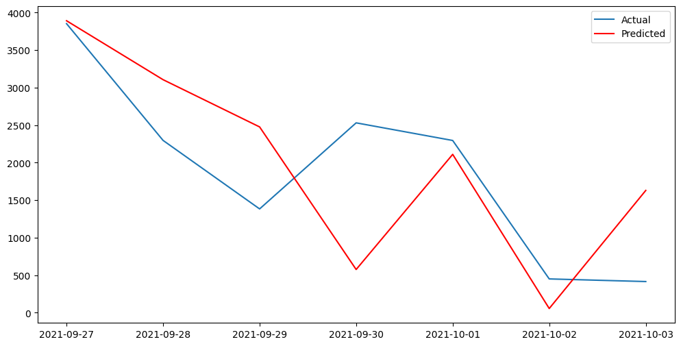

```python
plt.figure(figsize=(12,6))

plt.plot(prediction_test_date_co['actuals.newCases'], label='Actual')
plt.plot(prediction_test_date_co['predicted'], color='red', label='Predicted')
plt.legend()
plt.show()
```

### F. Lag and VAR Model Optimization

```python
%%capture
from statsmodels.tools.eval_measures import aic


#Defining a function to find the optimal lag for VAR

def optimal_lag_var (x,data_x):

    aic_final_values = []

    for i in range(1, x+1):

        #fitting a VAR model for every number the given range
        model_evaluation = VAR(data_x)
        model_evaluation_fited = model_evaluation.fit(i)

        #calcution of aic for every lag in the given range
        aic_score = model_evaluation_fited.aic

        #store the lag order with its respective aic value

        aic_final_values.append((i, aic_score))

    return aic_final_values
```

```python
%%capture
#run the function to choose the best lag oder in a range of 1 to 10 incluse

aic_results = optimal_lag_var(10,co_cont_data)
```

```python
#Write a function to choose the best lag order
def lag_finder(result_x):
    b = [] #empty list for storing the lag order we want
    for i in result_x:
        if i[1]> 0:
            b.append(i)
    return min(b[1])
```

```python
#run the function to give us the lag
optimized_lag = lag_finder(aic_results)
optimized_lag
```

```
2
```

### Observation for 1st Prediction:

> The Optimal Lag number in this case is the same as what i used when runing the first prediction. No futher change to the model is required at this point.

# **2. 7-day average of daily new cases for every 7-day**

> **Data Curation:**

```python
sevenD_avg_data_fltrd.head()
```

|  | date | actuals.newCases | 7day_w_avg | y_lgd |
| --- | --- | --- | --- | --- |
| 7102 | 2021-08-23 | 3297.0 | NaN | NaN |
| 7103 | 2021-08-24 | 985.0 | NaN | NaN |
| 7104 | 2021-08-25 | 1623.0 | NaN | NaN |
| 7105 | 2021-08-26 | 2235.0 | NaN | NaN |
| 7106 | 2021-08-27 | 1426.0 | NaN | NaN |

```python
%%capture

# Prepare column names for prophet
sevenD_avg_train = sevenD_avg_train[['date','7day_w_avg','y_lgd']]
sevenD_avg_train.rename(columns={'date':'ds','7day_w_avg':'y'}, inplace=True)
sevenD_avg_train.head()
```

> Model Training

```python
''' Model Training: hyperparameters tested:
- change point prior scale,
- seasonlity prior scale,
- regressor '''

model_7dx = Prophet(changepoint_prior_scale=0.05, seasonality_prior_scale=0.151)

#model_7dx.add_regressor('y_lgd')

model_7dx_fit = model_7dx.fit(sevenD_avg_train)

pred_len = model_7dx_fit.make_future_dataframe(periods=7)
#pred_len['y_lgd'] = sevenD_avg_train['y_lgd'].iloc[-4]
model_7dx_fit_frcst = model_7dx_fit.predict(pred_len)

model_7dx_results = model_7dx_fit_frcst[['ds','yhat']].tail(7)
model_7dx_results['yhat'] = round(model_7dx_results['yhat'],1)
model_7dx_results.set_index('ds',inplace=True)
model_7dx_results
```

```
00:55:40 - cmdstanpy - INFO - Chain [1] start processing
00:55:41 - cmdstanpy - INFO - Chain [1] done processing
```

| ds | yhat |
| --- | --- |
| 2021-09-27 | 1891.6 |
| 2021-09-28 | 1914.0 |
| 2021-09-29 | 1898.4 |
| 2021-09-30 | 1900.8 |
| 2021-10-01 | 1901.0 |
| 2021-10-02 | 1870.6 |
| 2021-10-03 | 1879.9 |

> **Result Visualization:**

```python
viz_7dx_df = sevenD_avg_test.copy()
viz_7dx_df['pred'] = model_7dx_results['yhat']
#viz_7dx_df
```

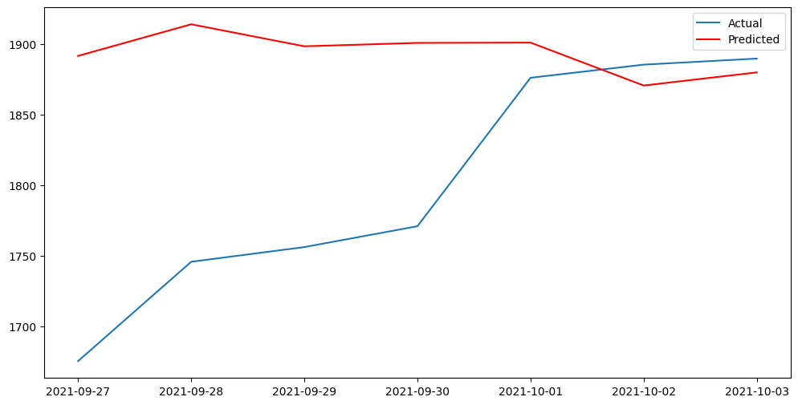

```python
plt.figure(figsize=(12,6))

plt.plot(viz_7dx_df['y'], label='Actual')
plt.plot(viz_7dx_df['pred'], color='red', label='Predicted')
plt.legend()
plt.show()
```

> **Mean Absolut Error:**

```python
pred_7d1 = viz_7dx_df['pred']
test_7d1 = viz_7dx_df['y']

mae_7d1 = round(mean_absolute_error(test_7d1,pred_7d1),1)
mae_7d1
```

```
100.9
```

> **Root Mean Squared Error:**

```python
rmse_7d1 = round(np.sqrt(mean_squared_error(test_7d1,pred_7d1)),4)
rmse_7d1
```

```
127.1495
```

# **3. Predicting Positivity Rate for the 7 Days:**

### A. Preprocessing and Feature Engineering

### B. Train The Model

##### Model Training with prohet

```python
#Create an insance of prophet model
prophet_model = Prophet(changepoint_prior_scale=2, seasonality_prior_scale=1, seasonality_mode='multiplicative', holidays=None)

#train the model
prophet_model.fit(prophet_train_data)

#define how many days we're predicting for
prediction_len = prophet_model.make_future_dataframe(periods=7)

#make the prediction
prophet_forcast = prophet_model.predict(prediction_len)

#select the two columns needed
filtered_forcast = prophet_forcast[['ds','yhat']]

#select the dates we predicted
forcasted_dates = filtered_forcast.iloc[28:, :]

#rounding
forcasted_dates.iloc[:,1:] = round(forcasted_dates.iloc[:,1:],3)
```

```
00:58:32 - cmdstanpy - INFO - Chain [1] start processing
00:58:34 - cmdstanpy - INFO - Chain [1] done processing
```

### C. Model Evaluation

> create dataset from actual data

```python
forcasted_dates
```

|  | ds | yhat |
| --- | --- | --- |
| 28 | 2021-09-27 | 0.074 |
| 29 | 2021-09-28 | 0.074 |
| 30 | 2021-09-29 | 0.073 |
| 31 | 2021-09-30 | 0.072 |
| 32 | 2021-10-01 | 0.071 |
| 33 | 2021-10-02 | 0.071 |
| 34 | 2021-10-03 | 0.071 |

```python
#Experiment data
test_dx = fltrd_eval_data['true_values']
train_d = prophet_train_data
```

```python
metrics_mae = round(mean_absolute_error(fltrd_eval_data['true_values'], fltrd_eval_data['prediction']),4)

metrics_mae
```

```
0.004
```

> Mean Squared Error

```python
metrics_rmse = round(np.sqrt(mean_squared_error(fltrd_eval_data['true_values'], fltrd_eval_data['prediction'])),4)
metrics_rmse
```

```
0.0044
```

### Visualization of Result

```python
fltrd_eval_data
```

| ds | true_values | prediction |
| --- | --- | --- |
| 2021-09-27 | 0.068 | 0.074 |
| 2021-09-28 | 0.069 | 0.074 |
| 2021-09-29 | 0.072 | 0.073 |
| 2021-09-30 | 0.073 | 0.072 |
| 2021-10-01 | 0.076 | 0.071 |
| 2021-10-02 | 0.076 | 0.071 |
| 2021-10-03 | 0.076 | 0.071 |

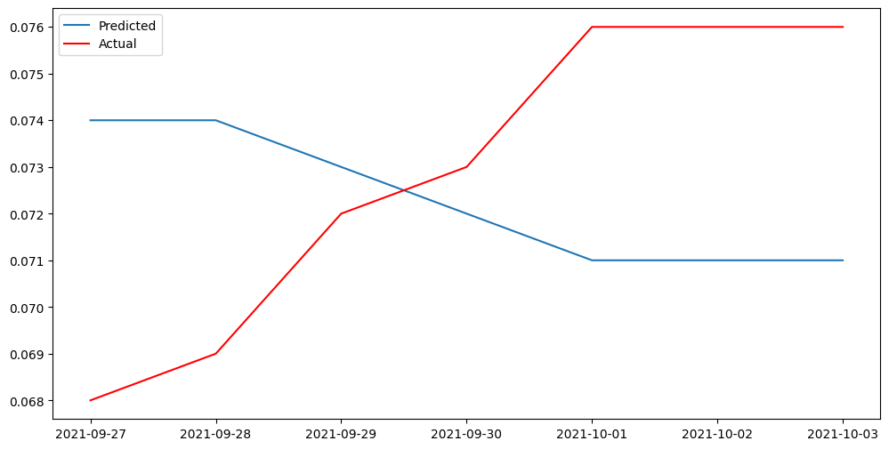

```python
plt.figure(figsize=(12,6))

plt.plot(fltrd_eval_data['prediction'], label='Predicted')
plt.plot(fltrd_eval_data['true_values'], color='red', label='Actual')
plt.legend()
plt.show()
```

### E. Model Optimization

> Finding optimal parameters

```python
#Change point prior scale

def optimal_prophet_params(cpps,snps):

    exp_model = Prophet(changepoint_prior_scale=cpps, seasonality_prior_scale=snps)            #set params
    exp_model_fit = exp_model.fit(train_d)                       #fit the data

    exp_days = exp_model.make_future_dataframe(periods=7)        #set number of day predicting for
    exp_forecast = exp_model_fit.predict(exp_days)               #make the forecast

    pred_d = exp_forecast['yhat'].tail(7)                        #selected predicted data

    rmse = np.sqrt(mean_squared_error(pred_d,test_dx))           #caluclate the mse

    return rmse                                                  #Return rMSE value
```

```python
%%capture
from sklearn.model_selection import ParameterGrid

# run function and search for optiomal param

#optimal_change_pt = None
#optimal_seasonality = None
best_params = None
optimal_rmse = float('inf')

parameter_grid = {

    'cpps':[0.01, 0.05, 0.07, 0.1, 0.15, 0.2, 0.25, 0.35, 0.5, 0.7, 0.75, 1.0, 1.25, 1.5],
    'snps':[0.01, 0.05, 0.07, 0.1, 0.15, 0.2, 0.25, 0.35, 0.5, 0.7, 0.75, 1.0, 1.25, 1.5]
}
for b_params in ParameterGrid(parameter_grid):
    exp_rmse =optimal_prophet_params(**b_params)

    if exp_rmse < optimal_rmse:
        optimal_rmse = round(exp_rmse,4)
        best_params = b_params
```

[output not shown]

[output cut: 337 more lines]

[output not shown]

```python
final_prophet_model = Prophet(changepoint_prior_scale=b_params['cpps'], seasonality_prior_scale=b_params['snps'])
final_prophet_model_fit = final_prophet_model.fit(prophet_train_data)

final_future_days = final_prophet_model.make_future_dataframe(periods=7)
final_prophet_prediction = final_prophet_model_fit.predict(final_future_days)
```

```
01:06:33 - cmdstanpy - INFO - Chain [1] start processing
01:06:35 - cmdstanpy - INFO - Chain [1] done processing
```

```python
true_viz_data
```

| ds | true_values | prediction |
| --- | --- | --- |
| 2021-09-27 | 0.068 | 0.074 |
| 2021-09-28 | 0.069 | 0.074 |
| 2021-09-29 | 0.072 | 0.073 |
| 2021-09-30 | 0.073 | 0.072 |
| 2021-10-01 | 0.076 | 0.071 |
| 2021-10-02 | 0.076 | 0.071 |
| 2021-10-03 | 0.076 | 0.071 |

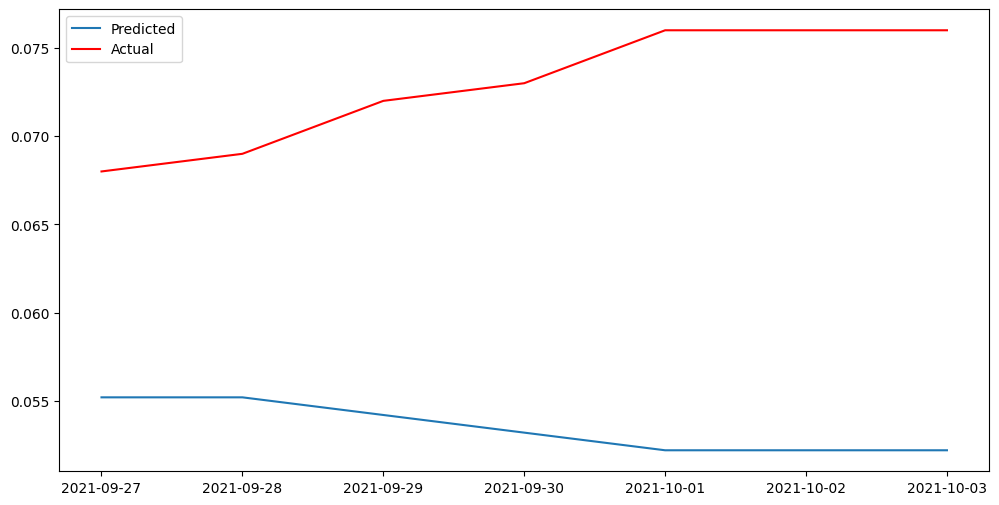

```python
#Plot the results to visualize prediction
plt.figure(figsize=(12,6))
plt.plot(pred_viz_data['yhat'], label='Predicted')
plt.plot(true_viz_data['true_values'], color='red', label='Actual')
plt.legend()
plt.show()
```

# **4. 7-day average of the positivity rate**

> Data Curation

> 7 Day rolling average Calculation

```python
#The seven day average of daily positivity for each day is calculate here, rounded to 3 decimal points
sevenD_Positivity_data['7day_window'] = sevenD_Positivity_data['metrics.testPositivityRatio'].rolling(window=7).mean()
sevenD_Positivity_data['7day_window'] = round(sevenD_Positivity_data['7day_window'],3)
```

> Model Training

```python
#define model hyper parameters
model_7dx2 = Prophet(changepoint_prior_scale= 0.152, seasonality_prior_scale=0.01, seasonality_mode='multiplicative')

#fitting the model with the training data
model_7dx2_fit = model_7dx2.fit(pos_train_data)

#set the number of prediction we're making
pos_days = model_7dx2_fit.make_future_dataframe(periods=13)

#Making the prediction
pos_forcast = model_7dx2_fit.predict(pos_days)

#Selecting the result we're looking for
pos_result = pos_forcast.tail(7)[['ds','yhat']]

#Format the result
pos_result['yhat'] = round(pos_result['yhat'],3)

#sample view of the result
pos_result
```

```
01:12:50 - cmdstanpy - INFO - Chain [1] start processing
01:12:58 - cmdstanpy - INFO - Chain [1] done processing
```

[output not shown]

> Result Visualization

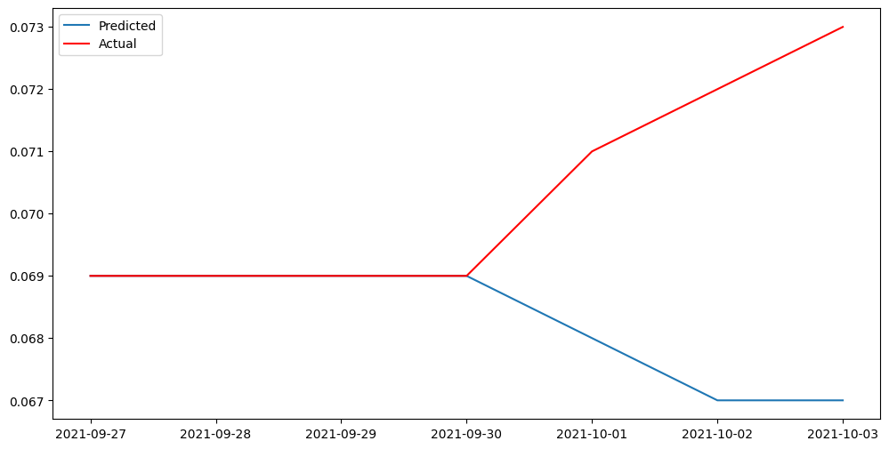

```python
plt.figure(figsize=(12,6)) #set figure size

plt.plot(pos_viz_data['yhat'], label='Predicted') #select the predicted value

plt.plot(pos_viz_data['true_val'], color='red', label='Actual') #select the test data

plt.legend() #show legends

plt.show()
```

> Metrics Evaluation: Mean Absolute Error

```python
#Calculation of mean MAE

pos_mae = round(mean_absolute_error(pos_viz_data['true_val'], pos_viz_data['yhat']),4)

#print MAE
pos_mae
```

```
0.002
```

> Metrics Evaluation: Root Mean Squared Error

```python
#calculation
pos_rmse = round(np.sqrt(mean_squared_error(pos_viz_data['true_val'], pos_viz_data['yhat'])),4)

#print result
pos_rmse
```

```
0.0032
```